# WhiteMatterDevelopment

Benjamin Risk

2/14/2022

` ## Data prep

First, create a dataset with each ROI by DTI metric as a column. The data are provided in long format, and this converts the data to wide format. This also stacks that whole brain data with the regional data.

```r
# NOTE: deleted a space and copy and paste to get columns to align
dat.a = read.delim('dti_data_extracted_by_tracts_all_atlas_symmetry_xyflipped_2_TnP2020.txt',sep=" ",stringsAsFactors = TRUE)

dat.b = read.delim('dti_data_extracted_by_tracts_all_atlas_symmetry_xyflipped_2_TnP2020_bin.txt',sep=" ",stringsAsFactors = TRUE)

all(names(dat.a)==names(dat.b))

dat = rbind(dat.a,dat.b)

dat$Scanner = as.factor(ifelse(dat$ifPrisma==0,'trio','prisma'))

table(dat$ROI)
table(dat[dat$DTI_type=='fa' & dat$ROI=='CCb','Unique_ID'])
# participants vary from 1 to 3 visits
table(table(dat[dat$DTI_type=='fa' & dat$ROI=='CCb','Unique_ID']))
# 41 infants have 1 visit, 26 have 2, and 12 have 3


# make data wide:
library(tidyr)
names(dat)
dat$feature_names = paste0(dat$ROI,'_',dat$DTI_type)
dat2 = dat[,c('GA','chor_age','Corr_age','Sex','Unique_ID','DTI_val','ifPrisma','Scanner','feature_names')]
dat_wide = dat2%>%pivot_wider(names_from=feature_names,values_from='DTI_val')
```

## Apply longitudinal combat and investigate scanner effects

Construct a b-spline for corrected age. Then longitudinal combat will use this spline for corrected age. We used df=5 to capture a relatively simple curve, since the effective degrees of freedom from initial GAMMs indicated effective degrees of freedom of 3-4 in the penalized spline approach. Based on inspetion, the results appear relatively robust to this choice, although the spline may help to reduce some scanner effects.

Note, longitudinal combat models the batch effect on the mean as an intercept, i.e., shift up or down in the developmental trajectory. Current harmonization methods do not allow batch effects to cause different curves. Thus, it is important to check that there are not substantial interactions between batch (here, scanner) and the develomental trajectory, i.e., that the curves do not substantially differ on the trio and prisma scanners.

```r
library(longCombat)
# reshape wide to get input features for longitudinal combat
feature_names=names(dat_wide)[8:55]
detach('package:tidyr',unload=TRUE)
degreesfreedom=5
temp = splines::bs(dat_wide$Corr_age,df=degreesfreedom)
temp = data.frame(temp)
names(temp) = paste0("Corr_age",1:degreesfreedom)
dat_wide = cbind(dat_wide,temp)

  # check the spline fit:
  # model.test = lm(dat_wide$AF_fa~as.matrix(temp))
  # plot(predict(model.test)~dat_wide$Corr_age)

dat_combat <- longCombat(idvar='Unique_ID',
                             timevar='Corr_age',
                             batchvar='Scanner',
                             features=feature_names,
                             formula='Corr_age1 + Corr_age2+ Corr_age3 + Corr_age4 + Corr_age5+Sex',
                            #formula='Corr_age + Sex', # note: linear vs spline seem similar
                             ranef='(1|Unique_ID)',
                             data=dat_wide)
```

[output not shown]

[output cut: 31 more lines]

[output not shown]

```r
dat_harmonized <- merge(dat_wide, dat_combat$data_combat, by=c('Unique_ID', 'Corr_age','Scanner'))
```

## Check the harmonization in a few features

Next, we examine whether combat reduced batch effects. This code also allows a comparison of the curves in the trio and prisma scanners.

```r
library(mgcv)
library(itsadug)
```

```r
examine_combat = function(feature,feature.combat,dataset) {

  model0 = gam(feature~s(Corr_age,by=Scanner,bs='bs')+s(GA,k=5,bs='bs')+Sex+s(Unique_ID,bs='re')+Scanner,method='REML',data=dataset)

  model0.harm = gam(feature.combat~s(Corr_age,by=Scanner,bs='bs')+s(GA,k=5,bs='bs')+Sex+s(Unique_ID,bs='re')+Scanner,method='REML',data=dataset)
  par(mfrow=c(2,3))
  plot_smooth(model0,view="Corr_age",cond=list(Scanner='trio'),col='red',print.summary=FALSE)
  plot_smooth(model0, view="Corr_age", cond=list(Scanner='prisma'), add=TRUE, col='blue',print.summary=FALSE)
  plot_diff(model0,view='Corr_age',comp=list(Scanner=c('trio','prisma')),print.summary=FALSE)
  boxplot(resid(model0)~dataset$Scanner,ylab='residual - no harmonize',xlab='Scanner')

  plot_smooth(model0.harm,view="Corr_age",cond=list(Scanner='trio'),col='red',print.summary=FALSE)
  plot_smooth(model0.harm, view="Corr_age", cond=list(Scanner='prisma'), add=TRUE, col='blue',print.summary=FALSE)
  plot_diff(model0.harm,view='Corr_age',comp=list(Scanner=c('trio','prisma')),print.summary=FALSE)
  boxplot(resid(model0.harm)~dataset$Scanner,ylab='residual - harmonized',xlab='Scanner')
}
```

Examine the whole brain curves:

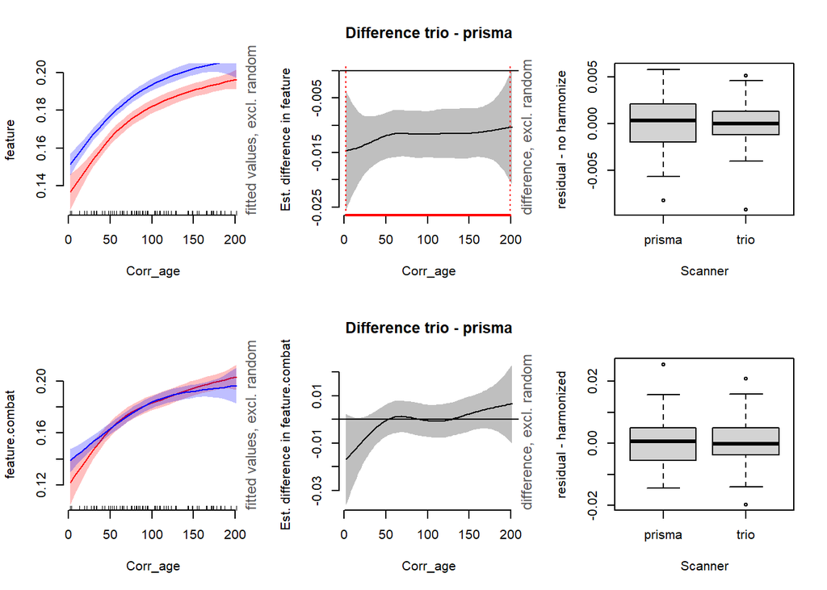

```r
examine_combat(dat_harmonized$WB_fa,dat_harmonized$AF_fa.combat,dat_harmonized)
```

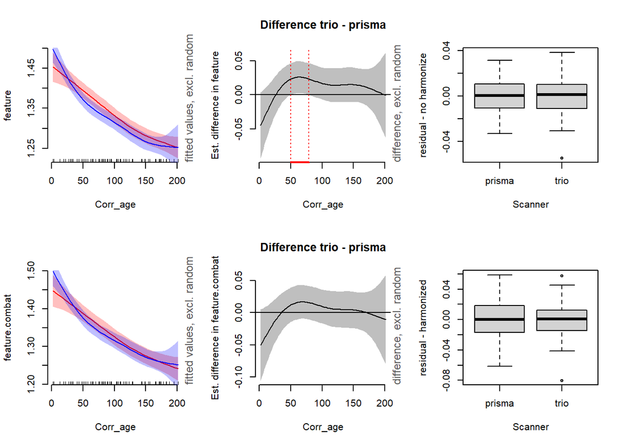

```r
examine_combat(dat_harmonized$WB_ad,dat_harmonized$WB_ad.combat,dat_harmonized)
```

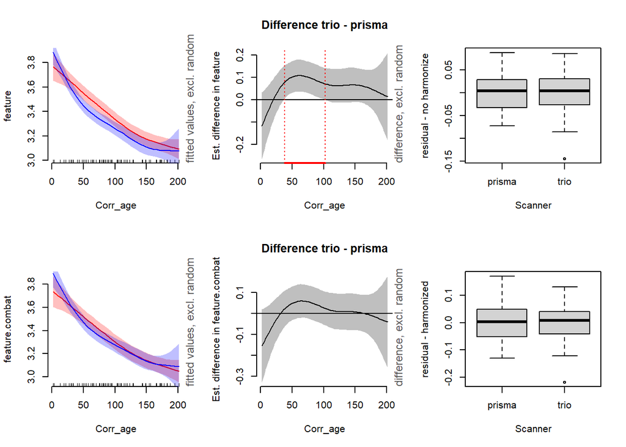

```r
examine_combat(dat_harmonized$WB_tr,dat_harmonized$WB_tr.combat,dat_harmonized)
```

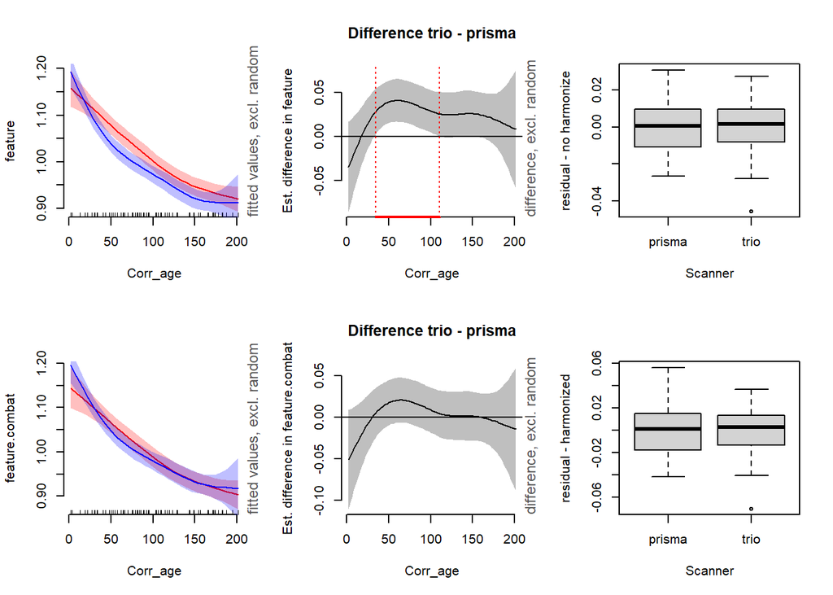

```r
examine_combat(dat_harmonized$WB_rd,dat_harmonized$WB_rd.combat,dat_harmonized)
```

Combat is helping to remove the shift in the mean. I don’t see much change in the variances, though, as indicated by the IQR. In my opinion, we could just control for scanner effects in the mean model, since the variances don’t seem harmonized. On the other hand, since combat is regarded as a more thorough approach, we can continue with combat.

Examine a few of the trajectories in different ROIs:

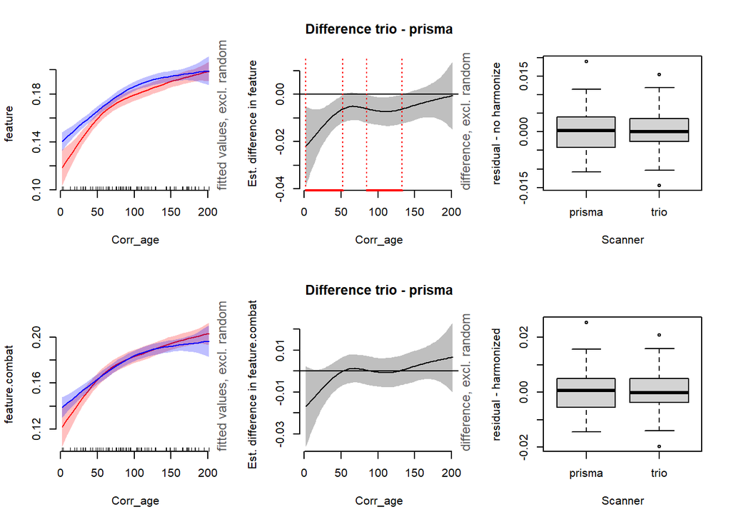

```r
examine_combat(dat_harmonized$AF_fa,dat_harmonized$AF_fa.combat,dat_harmonized)
```

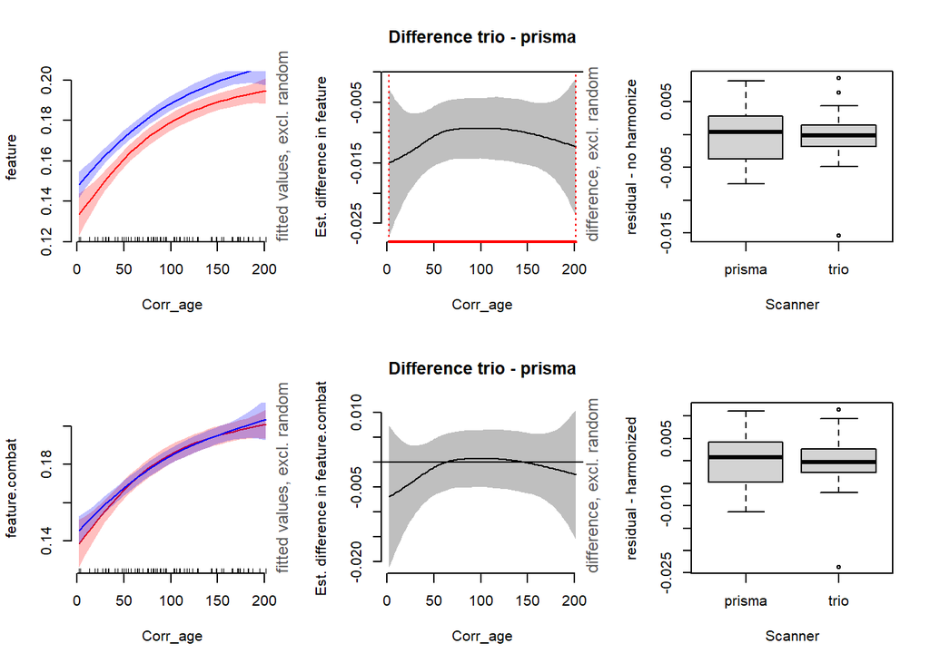

```r
examine_combat(dat_harmonized$CCg_fa,dat_harmonized$CCg_fa.combat,dat_harmonized)
```

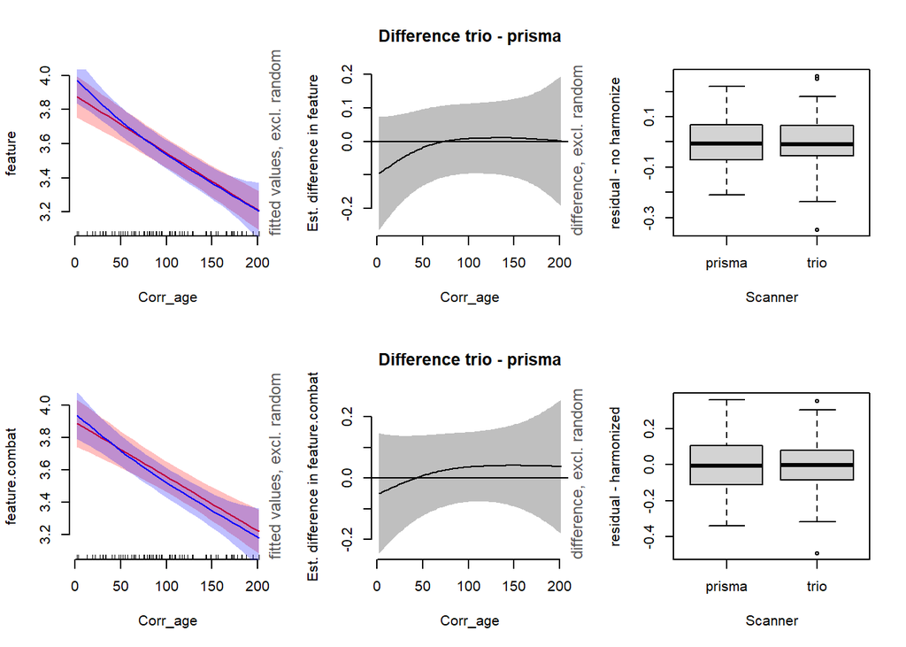

```r
examine_combat(dat_harmonized$CCg_tr,dat_harmonized$CCg_tr.combat,dat_harmonized)
```

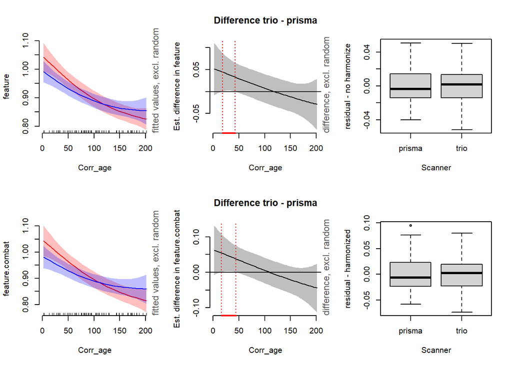

```r
examine_combat(dat_harmonized$PT_rd,dat_harmonized$PT_rd.combat,dat_harmonized)
```

## Examine the interaction between gestational age and chronological age

Fit a bivariate spline. This section uses FA.

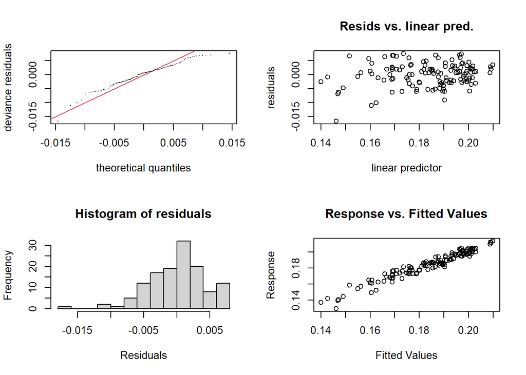

```
##
## Method: REML   Optimizer: outer newton
## full convergence after 9 iterations.
## Gradient range [-0.0002015356,5.607112e-05]
## (score -419.4459 & scale 3.008644e-05).
## Hessian positive definite, eigenvalue range [0.0002012772,70.96291].
## Model rank =  115 / 115
##
## Basis dimension (k) checking results. Low p-value (k-index<1) may
## indicate that k is too low, especially if edf is close to k'.
##
##                    k'   edf k-index p-value
## s(chor_age)      9.00  3.56    0.81    0.02 *
## s(GA)            9.00  1.98    1.11    0.90
## ti(chor_age,GA) 16.00  1.96    1.07    0.81
## s(Unique_ID)    79.00 45.20      NA      NA
## ---
## Signif. codes:  0 '***' 0.001 '**' 0.01 '*' 0.05 '.' 0.1 ' ' 1
```

```r
model0 = gam(WB_fa.combat~s(chor_age)+s(GA)+ti(chor_age,GA)+Sex+s(Unique_ID,bs='re'),method='REML',data=dat_harmonized)
gam.check(model0) # edf are all far from k', so the default k's suffice.
```

```r
summary(model0)
```

```
##
## Family: gaussian
## Link function: identity
##
## Formula:
## WB_fa.combat ~ s(chor_age) + s(GA) + ti(chor_age, GA) + Sex +
##     s(Unique_ID, bs = "re")
##
## Parametric coefficients:
##               Estimate Std. Error t value Pr(>|t|)
## (Intercept)  0.1837515  0.0013429 136.831   <2e-16 ***
## SexM        -0.0006854  0.0017258  -0.397    0.692
## ---
## Signif. codes:  0 '***' 0.001 '**' 0.01 '*' 0.05 '.' 0.1 ' ' 1
##
## Approximate significance of smooth terms:
##                    edf Ref.df       F  p-value
## s(chor_age)      3.562  4.227 141.661  < 2e-16 ***
## s(GA)            1.982  2.192  16.559 7.80e-07 ***
## ti(chor_age,GA)  1.960  2.284   5.581  0.00392 **
## s(Unique_ID)    45.197 76.000   1.659 6.03e-06 ***
## ---
## Signif. codes:  0 '***' 0.001 '**' 0.01 '*' 0.05 '.' 0.1 ' ' 1
##
## R-sq.(adj) =  0.897   Deviance explained =   94%
## -REML = -419.45  Scale est. = 3.0086e-05  n = 129
```

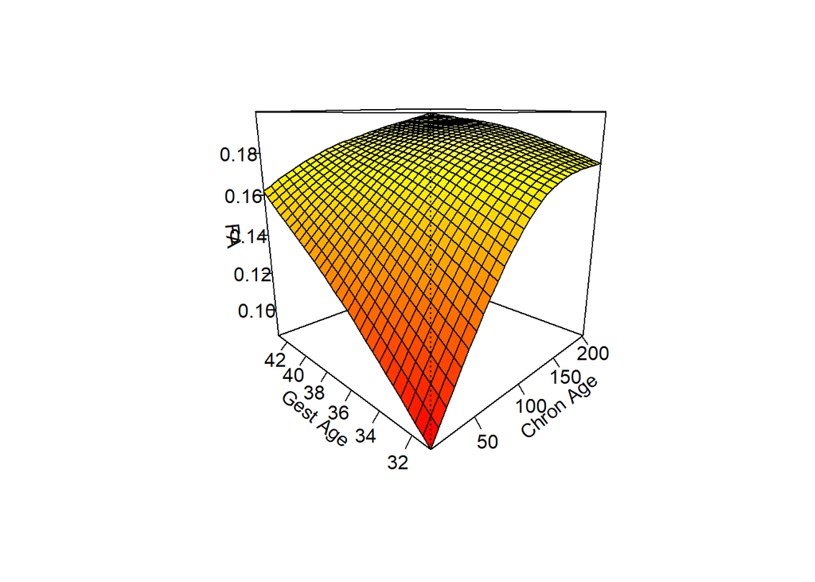

```r
vis.gam(model0,view=c('chor_age','GA'),theta=-45,ticktype='detailed',xlab='Chron Age',ylab='Gest Age',zlab='FA')
```

```r
plot_smooth(model0, view="chor_age", cond=list(GA=36),xlab='Chronological Age',col='purple')
```

```
## Summary:
##  * Sex : factor; set to the value(s): M.
##  * chor_age : numeric predictor; with 30 values ranging from 10.000000 to 202.000000.
##  * GA : numeric predictor; set to the value(s): 36.
##  * Unique_ID : factor; set to the value(s): 00106_04. (Might be canceled as random effect, check below.)
##  * NOTE : The following random effects columns are canceled: s(Unique_ID)
##
```

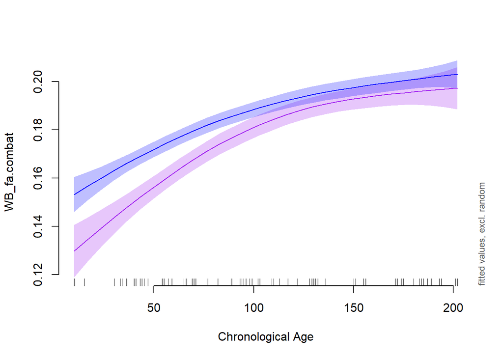

```
## Summary:
##  * Sex : factor; set to the value(s): M.
##  * chor_age : numeric predictor; with 30 values ranging from 10.000000 to 202.000000.
##  * GA : numeric predictor; set to the value(s): 40.
##  * Unique_ID : factor; set to the value(s): 00106_04. (Might be canceled as random effect, check below.)
##  * NOTE : The following random effects columns are canceled: s(Unique_ID)
##
```

```r
plot_smooth(model0, view="chor_age", cond=list(GA=40),xlab='Chronological Age',col='blue',add=TRUE)
```

Next, we check whether there is a significant interaction between gestational age and corrected age.

```r
model0.corr = gam(WB_fa.combat~s(Corr_age)+s(GA)+ti(Corr_age,GA)+Sex+s(Unique_ID,bs='re'),method='REML',data=dat_harmonized)
summary(model0.corr)
```

```
##
## Family: gaussian
## Link function: identity
##
## Formula:
## WB_fa.combat ~ s(Corr_age) + s(GA) + ti(Corr_age, GA) + Sex +
##     s(Unique_ID, bs = "re")
##
## Parametric coefficients:
##               Estimate Std. Error t value Pr(>|t|)
## (Intercept)  0.1839482  0.0013675 134.509   <2e-16 ***
## SexM        -0.0005628  0.0017487  -0.322    0.748
## ---
## Signif. codes:  0 '***' 0.001 '**' 0.01 '*' 0.05 '.' 0.1 ' ' 1
##
## Approximate significance of smooth terms:
##                    edf Ref.df       F  p-value
## s(Corr_age)      3.657  4.332 123.270  < 2e-16 ***
## s(GA)            1.874  2.083   1.369    0.231
## ti(Corr_age,GA)  1.837  2.158   0.983    0.362
## s(Unique_ID)    45.566 76.000   1.686 5.23e-06 ***
## ---
## Signif. codes:  0 '***' 0.001 '**' 0.01 '*' 0.05 '.' 0.1 ' ' 1
##
## R-sq.(adj) =  0.895   Deviance explained = 93.9%
## -REML = -418.17  Scale est. = 3.0582e-05  n = 129
```

```r
plot_smooth(model0.corr, view="Corr_age", cond=list(GA=36),xlab='Corrected Age',col='purple')
```

```
## Summary:
##  * Sex : factor; set to the value(s): M.
##  * Corr_age : numeric predictor; with 30 values ranging from 2.000000 to 201.000000.
##  * GA : numeric predictor; set to the value(s): 36.
##  * Unique_ID : factor; set to the value(s): 00106_04. (Might be canceled as random effect, check below.)
##  * NOTE : The following random effects columns are canceled: s(Unique_ID)
##
```

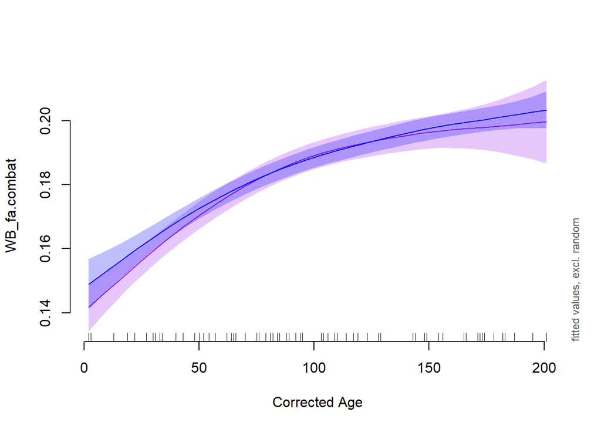

```
## Summary:
##  * Sex : factor; set to the value(s): M.
##  * Corr_age : numeric predictor; with 30 values ranging from 2.000000 to 201.000000.
##  * GA : numeric predictor; set to the value(s): 40.
##  * Unique_ID : factor; set to the value(s): 00106_04. (Might be canceled as random effect, check below.)
##  * NOTE : The following random effects columns are canceled: s(Unique_ID)
##
```

```r
plot_smooth(model0.corr, view="Corr_age", cond=list(GA=40),xlab='Corrected Age',col='blue',add=TRUE)
```

There is no interaction between gestational age and corrected age (p=0.36). The interaction observed with chronological age and gestational age appears to be driven by a shift in the curve, which is corrected when using the corrected age. The FA curve as function of corrected age is very similar for infants with GA=36 and 40.

Also, GA is not significant in this model.

## Examine whether the developmental trajectories differ between males and females.

```r
model.sex.fa = gam(WB_fa.combat~s(Corr_age,by=Sex)+Sex+s(Unique_ID,bs='re'),method='REML',data=dat_harmonized)
summary(model.sex.fa)
```

```
##
## Family: gaussian
## Link function: identity
##
## Formula:
## WB_fa.combat ~ s(Corr_age, by = Sex) + Sex + s(Unique_ID, bs = "re")
##
## Parametric coefficients:
##               Estimate Std. Error t value Pr(>|t|)
## (Intercept)  0.1838134  0.0013696 134.210   <2e-16 ***
## SexM        -0.0007775  0.0017507  -0.444    0.658
## ---
## Signif. codes:  0 '***' 0.001 '**' 0.01 '*' 0.05 '.' 0.1 ' ' 1
##
## Approximate significance of smooth terms:
##                     edf Ref.df       F  p-value
## s(Corr_age):SexF  2.523  3.033  56.077  < 2e-16 ***
## s(Corr_age):SexM  4.179  4.910 105.570  < 2e-16 ***
## s(Unique_ID)     51.505 77.000   2.229 4.96e-07 ***
## ---
## Signif. codes:  0 '***' 0.001 '**' 0.01 '*' 0.05 '.' 0.1 ' ' 1
##
## R-sq.(adj) =  0.912   Deviance explained = 95.2%
## -REML = -424.13  Scale est. = 2.5721e-05  n = 129
```

```
## Summary:
##  * Corr_age : numeric predictor; with 100 values ranging from 2.000000 to 201.000000.
##  * Unique_ID : factor; set to the value(s): 00106_04. (Might be canceled as random effect, check below.)
##  * NOTE : The following random effects columns are canceled: s(Unique_ID)
##
```

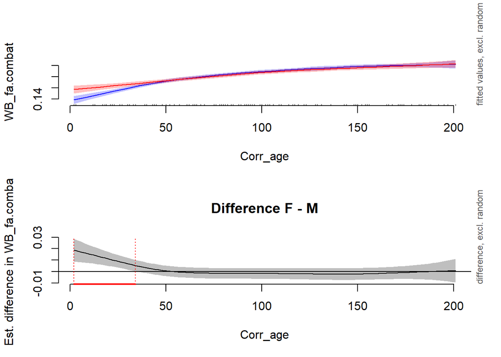

```
##
## Corr_age window(s) of significant difference(s):
##  2.000000 - 34.161616
```

```r
par(mfrow=c(2,1))
plot_smooth(model.sex.fa, view="Corr_age", cond=list(Sex='M'), col='blue',print.summary=FALSE)
plot_smooth(model.sex.fa,view="Corr_age",cond=list(Sex='F'),col='red',print.summary=FALSE,add=TRUE)

plot_diff(model.sex.fa,view='Corr_age',comp=list(Sex=c('F','M')))
```

Initially, females have higher FA than males. After approximately 34 days, the FA levels are similar.

We can also check the pattern in the not-harmonized data:

```
## Summary:
##  * Corr_age : numeric predictor; with 100 values ranging from 2.000000 to 201.000000.
##  * Unique_ID : factor; set to the value(s): 00106_04. (Might be canceled as random effect, check below.)
##  * NOTE : The following random effects columns are canceled: s(Unique_ID)
##
```

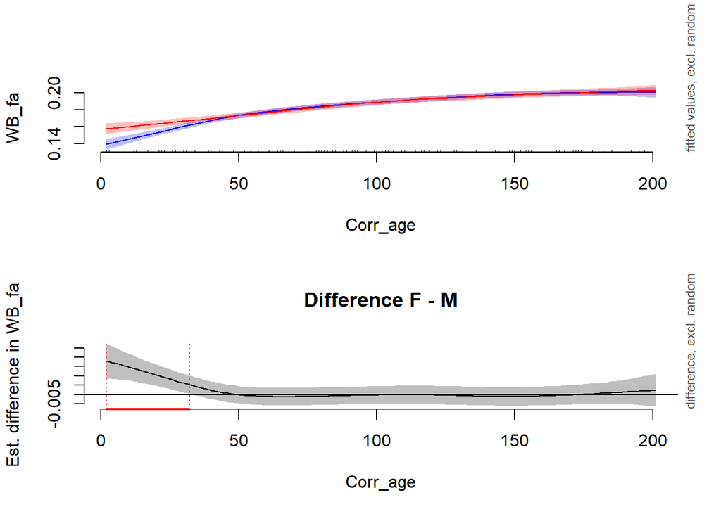

```
##
## Corr_age window(s) of significant difference(s):
##  2.000000 - 32.151515
```

```r
model.sex.fa.nocombat = gam(WB_fa~s(Corr_age,by=Sex)+Sex+s(Unique_ID,bs='re'),method='REML',data=dat_harmonized)

par(mfrow=c(2,1))
plot_smooth(model.sex.fa.nocombat, view="Corr_age", cond=list(Sex='M'), col='blue',print.summary=FALSE)
plot_smooth(model.sex.fa.nocombat,view="Corr_age",cond=list(Sex='F'),col='red',print.summary=FALSE,add=TRUE)

plot_diff(model.sex.fa.nocombat,view='Corr_age',comp=list(Sex=c('F','M')))
```

The results are very similar using the non-harmonized data.